# Report Exercise Stepwise Regression

bea cheda

2025-04-28

## Goal of the exercise

The goal of this exercise is to implement a stepwise forward regression to model GPP as a function of predictors available in the half-hourly ecosystem fluxes data set (data from FLUXNET).

### Load library

```r
library(tidyverse)
```

### Read data

```r
df_stepwise_regression <- readr::read_csv("../data/df_for_stepwise_regression.csv")
```

### Prepare setting for bivariate evaluation

```r
# Extract variable names without GPP
variable_names <- setdiff(names(df_stepwise_regression), c("GPP_NT_VUT_REF"))

# Set start variables/model to 0/NoData before running the loop
r2_final <- 0
best_var <- NA
best_model <- NULL
model_results <- tibble(variable = character(),
                        coefficient = numeric(), # create empty results' tibble
                        r_squared = numeric())
```

## Bivariate models’ comparison

Loop over the variable names. Create each time a linear model and fill the model results into a tibble. Compare models’ r.squared and save the highest.

### Choose bivariate model with best R Squared

```r
for(i in seq_along(variable_names)){ # loop over variables by name
  var_name <- variable_names[i]
  formula <- as.formula(paste("GPP_NT_VUT_REF", "~", var_name))
  linear_model <- lm(formula, data = df_stepwise_regression) # bivariate model
  r2 <- summary(linear_model)$r.squared # extract model's r squared

  # store model results
  model_results <- model_results |>
    add_row(variable = var_name,
            coefficient = coef(linear_model)[2],
            r_squared = r2)

  # overwrite best model if r squared is bigger
  if(r2 > r2_final){
    r2_final <- r2
    best_var <- var_name
    best_model <- linear_model
  }

}

summary(best_model)
```

```
##
## Call:
## lm(formula = formula, data = df_stepwise_regression)
##
## Residuals:
##     Min      1Q  Median      3Q     Max
## -8.0475 -1.3255 -0.3758  1.2780 12.3295
##
## Coefficients:
##             Estimate Std. Error t value Pr(>|t|)
## (Intercept)  0.72533    0.03057   23.73   <2e-16 ***
## PPFD_IN      0.01062    0.00009  117.98   <2e-16 ***
## ---
## Signif. codes:  0 '***' 0.001 '**' 0.01 '*' 0.05 '.' 0.1 ' ' 1
##
## Residual standard error: 2.41 on 16872 degrees of freedom
##   (6137 observations effacées parce que manquantes)
## Multiple R-squared:  0.4521, Adjusted R-squared:  0.452
## F-statistic: 1.392e+04 on 1 and 16872 DF,  p-value: < 2.2e-16
```

### Results of all bivariate models

Have a look at the results of all bivariate models. The best variable is highlighted in red.

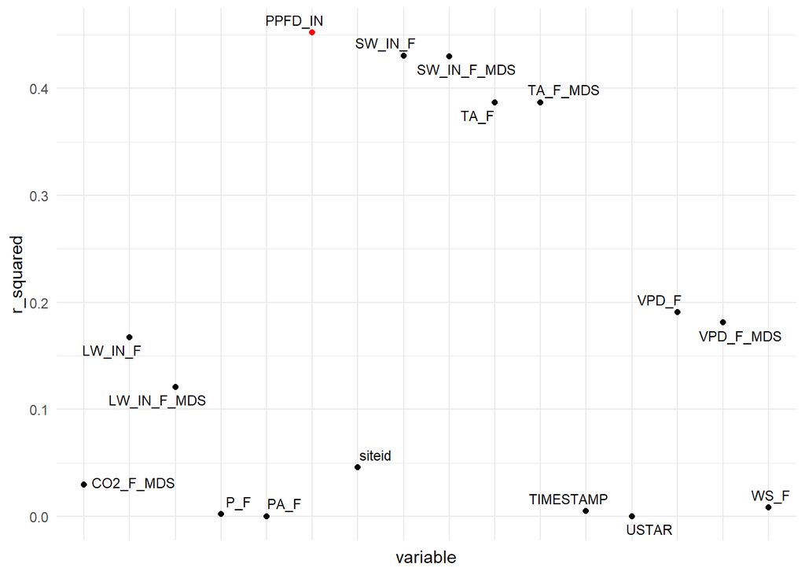

```r
ggplot(model_results, aes(x = variable, y = r_squared)) +
  geom_point(aes(color = r_squared == max(r_squared))) +
  ggrepel::geom_text_repel(aes(label = variable), size = 3) +
  scale_color_manual(values = c("FALSE" = "black", "TRUE" = "red")) +
  guides(color = "none") +
  theme_minimal() +
  theme(axis.text.x = element_blank(),
        axis.ticks.x = element_blank())
```

From the plot we can see that the bivariate model with the highest r.squared contains the variable PPFD_IN (incoming photosynthetic photon flux density). This model explains about 45% of the variation observed in GPP (r.squared = 0.452).

Other variables, such as incoming shortwave radiation and temperature (both the consolidated and the gapfilled versions) also demonstrate high r.squared values (around 0.4). It is therefore probable, that these variables will appear in our final model. However we can expect that each of the both variable will appear only in one form in the final model, since the consolidated and the gapfilled versions are highly correlated.

Further we can see that longwave radiation as well as vapor pressure deficit have both r.squared of between 0.1 and 0.2 while the other variables demonstrate r.squared values below 0.05. Those last variables are somewhat less likely to end up in our final model, since they don’t explain much of the variation in GPP.

## Set up for the stepwise forward regression

- Create a vector with the included variables (PPFD_IN at the beginning)
- Adapt formula and allow it to change dynamically in the loop
- Create a final_model and a current_aic objects. Fill these objects with the best bivariate model’s results.

  These initial values are to be overwritten in the loop when certain conditions are met. New “best” variables will be included in the included_variables vector and in the model’s formula. final_model and current_aic are overwritten only when the new AIC performs better than the one in the older model.
- Create a results_aic tibble, which will display the added variable and the corresponding AIC value after each iteration of the loop.

```r
included_variables <- c("PPFD_IN")
current_formula <- paste("GPP_NT_VUT_REF ~", paste(included_variables, collapse = " + "))
current_model <- lm(as.formula(current_formula), data = df_stepwise_regression)
final_model <- current_model
current_aic <- extractAIC(current_model)[2]
results_aic <- tibble(added = character(),
                      aic = numeric())
```

### While loop setting

```r
continue <- TRUE


while(continue){
  # set initial values
  best_r2 <- 0
  best_aic <- current_aic
  best_var <- NULL
  best_model <- NULL


  for(i in seq_along(variable_names)){ # loop over variables by name
    var_name <- variable_names[i]
    test_formula <- paste(current_formula, "+", var_name) # adapt formula
    # create new test model by adding the variable
    test_model <- lm(as.formula(test_formula), data = df_stepwise_regression)
    # extract r squared
    test_r2 <- summary(test_model)$r.squared


    # select model with highest r squared and retain the added variable
    if(test_r2 > best_r2){
    best_r2 <- test_r2
    best_var <- var_name
    best_model <- test_model
    }

  }
    # compare new "best" model's AIC with previous AIC
    if(extractAIC(best_model)[2] < current_aic){ # check if new AIC is better
      # if yes

      # overwrite AIC
      current_aic <- extractAIC(best_model)[2]
      # add new variable to the included variables
      included_variables <- c(included_variables, best_var)
      # cancel newly included variable from the names' vector
      variable_names <- setdiff(variable_names, best_var)
      # adapt model formula with new variable
      current_formula <- paste("GPP_NT_VUT_REF ~", paste(included_variables, collapse = " + "))

      # store AIC results
      results_aic <- results_aic |>
       add_row(added = best_var,
               aic = current_aic)

     # overwrite final model with new best model
     final_model <- best_model

    }else{

      continue <- FALSE # stop loop if new model doesn't improve AIC
    }
}


print(results_aic)
```

```
## # A tibble: 9 × 2
##   added        aic
##   <chr>      <dbl>
## 1 LW_IN_F   27097.
## 2 siteid    24464.
## 3 VPD_F     23699.
## 4 TA_F_MDS  22354.
## 5 SW_IN_F   22073.
## 6 WS_F      21830.
## 7 CO2_F_MDS 21797.
## 8 P_F       21770.
## 9 PA_F      21762.
```

## Final model

Our final model contains the following variables:

- Incoming photosynthetic flux density
- Incoming long wave radiation
- Site id (reference category is Davos by default)
- Vapor pressure deficit
- Temperature
- Short wave radiation
- Wind speed
- CO2 mole fraction
- Precipitation
- Atmospheric pressure

Not included are: time of measurement and friction velocity. Further, other versions of long and short wave radiation, temperature as well as vapor pressure deficit are logically not included in the final model, since they are highly correlated with the corresponding variables already included in the model. The same explanation is probably also valid for the time of measurement. Besides having a very low r.squared value in the bivariate regression model (r.squared = 0.005), it is also probably correlated to seasonal varying predictors such as radiation and temperature.

```r
summary(best_model) #last model, that failed to improve aic
```

```
##
## Call:
## lm(formula = as.formula(test_formula), data = df_stepwise_regression)
##
## Residuals:
##     Min      1Q  Median      3Q     Max
## -8.3803 -1.1726 -0.0431  1.1877 11.4929
##
## Coefficients:
##                Estimate Std. Error t value Pr(>|t|)
## (Intercept)  -4.833e+00  1.609e+00  -3.004  0.00267 **
## PPFD_IN       3.098e-03  4.833e-04   6.411 1.49e-10 ***
## LW_IN_F       7.823e-03  6.821e-04  11.469  < 2e-16 ***
## siteidCH-Lae  8.313e-01  1.889e-01   4.400 1.09e-05 ***
## siteidFI-Hyy -5.900e-02  2.974e-01  -0.198  0.84274
## siteidFR-Pue -1.834e+00  2.782e-01  -6.590 4.52e-11 ***
## VPD_F        -3.238e-01  7.285e-03 -44.455  < 2e-16 ***
## TA_F_MDS      1.659e-01  4.972e-03  33.361  < 2e-16 ***
## SW_IN_F       1.680e-02  9.998e-04  16.808  < 2e-16 ***
## WS_F         -1.900e-01  1.355e-02 -14.020  < 2e-16 ***
## CO2_F_MDS    -3.826e-03  8.153e-04  -4.693 2.71e-06 ***
## P_F          -1.290e-02  2.495e-03  -5.172 2.35e-07 ***
## PA_F          5.735e-02  1.827e-02   3.139  0.00170 **
## TIMESTAMP    -6.450e-06  1.047e-05  -0.616  0.53783
## ---
## Signif. codes:  0 '***' 0.001 '**' 0.01 '*' 0.05 '.' 0.1 ' ' 1
##
## Residual standard error: 1.905 on 16860 degrees of freedom
##   (6137 observations effacées parce que manquantes)
## Multiple R-squared:  0.6579, Adjusted R-squared:  0.6577
## F-statistic:  2494 on 13 and 16860 DF,  p-value: < 2.2e-16
```

The last tested model, which failed to improve AIC, contained the time variable. We can see from the model summary, that the coefficient of that variable is highly insignificant (p value = 0.54), which is also a hint, that the variable actually should be excluded from the model. In the bivariate model, the coefficient of the time variable was highly significant though (see summary below), which supports the hypothesis that it correlates with other variables already included in the model and therefore “loses” its explanatory character once those other variables are part of the model.

```r
summary(lm(GPP_NT_VUT_REF ~ TIMESTAMP, data = df_stepwise_regression))
```

```
##
## Call:
## lm(formula = GPP_NT_VUT_REF ~ TIMESTAMP, data = df_stepwise_regression)
##
## Residuals:
##      Min       1Q   Median       3Q      Max
## -10.4064  -2.6903  -0.6691   2.1040  14.7671
##
## Coefficients:
##              Estimate Std. Error t value Pr(>|t|)
## (Intercept) 1.865e+00  1.661e-01  11.226   <2e-16 ***
## TIMESTAMP   1.212e-04  1.217e-05   9.956   <2e-16 ***
## ---
## Signif. codes:  0 '***' 0.001 '**' 0.01 '*' 0.05 '.' 0.1 ' ' 1
##
## Residual standard error: 3.177 on 20583 degrees of freedom
##   (2426 observations effacées parce que manquantes)
## Multiple R-squared:  0.004792,   Adjusted R-squared:  0.004744
## F-statistic: 99.11 on 1 and 20583 DF,  p-value: < 2.2e-16
```

## Interpretation of the results

Below is the summary of the final model retained by the stepwise forward regression:

```r
summary(final_model)
```

```
##
## Call:
## lm(formula = as.formula(test_formula), data = df_stepwise_regression)
##
## Residuals:
##     Min      1Q  Median      3Q     Max
## -8.3851 -1.1716 -0.0447  1.1883 11.4994
##
## Coefficients:
##                Estimate Std. Error t value Pr(>|t|)
## (Intercept)  -4.8774501  1.6075421  -3.034  0.00242 **
## PPFD_IN       0.0030746  0.0004818   6.382 1.79e-10 ***
## LW_IN_F       0.0078419  0.0006814  11.508  < 2e-16 ***
## siteidCH-Lae  0.8320302  0.1889169   4.404 1.07e-05 ***
## siteidFI-Hyy -0.0549576  0.2973224  -0.185  0.85336
## siteidFR-Pue -1.8297665  0.2781547  -6.578 4.90e-11 ***
## VPD_F        -0.3237971  0.0072843 -44.452  < 2e-16 ***
## TA_F_MDS      0.1656257  0.0049563  33.417  < 2e-16 ***
## SW_IN_F       0.0168497  0.0009972  16.898  < 2e-16 ***
## WS_F         -0.1895637  0.0135336 -14.007  < 2e-16 ***
## CO2_F_MDS    -0.0040374  0.0007395  -5.459 4.84e-08 ***
## P_F          -0.0128569  0.0024938  -5.155 2.56e-07 ***
## PA_F          0.0576619  0.0182668   3.157  0.00160 **
## ---
## Signif. codes:  0 '***' 0.001 '**' 0.01 '*' 0.05 '.' 0.1 ' ' 1
##
## Residual standard error: 1.905 on 16861 degrees of freedom
##   (6137 observations effacées parce que manquantes)
## Multiple R-squared:  0.6579, Adjusted R-squared:  0.6577
## F-statistic:  2702 on 12 and 16861 DF,  p-value: < 2.2e-16
```

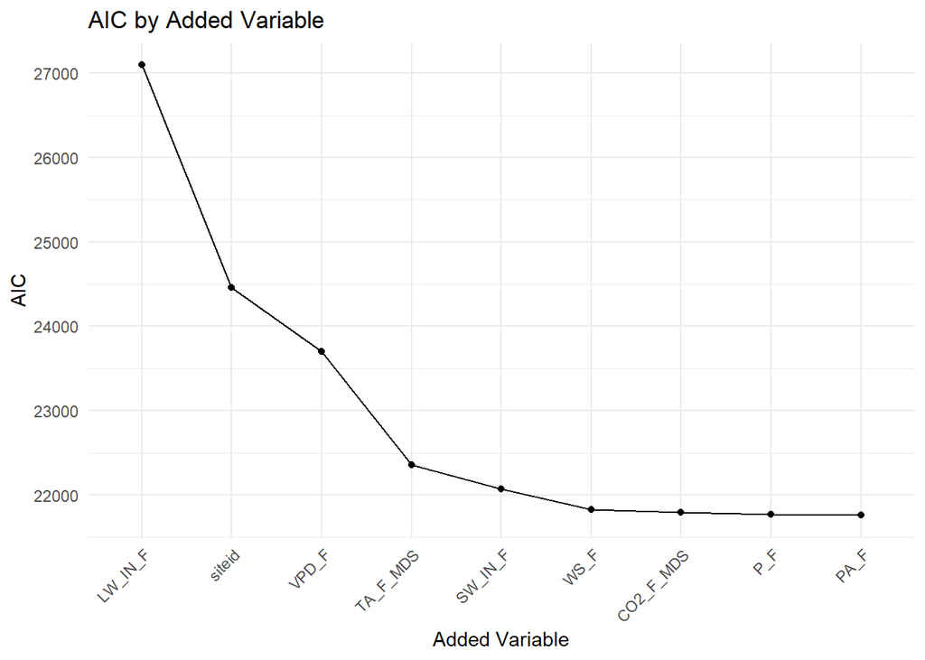

```r
ggplot(results_aic, aes(x = factor(added, levels = added),
                        y = aic)) +
  geom_line(group = 1) +
  geom_point() +
  labs(title = "AIC by Added Variable", x = "Added Variable", y = "AIC") +
  theme_minimal() +
  theme(axis.text.x = element_text(angle = 45, hjust = 1))
```

### Evolution of AIC

From this plot representing the evolution of the AIC during the stepwise forward regression, we see that its value improves greatly with the first four variables (incoming long wave radiation, site id, vapor pressure deficit and temperature). After that, the curve flattens with the introduction of the incoming shortwave radiation and the wind speed. For the last three variables (CO2 mole fraction, precipitation and atmospheric pressure) the difference in the AIC value is very small. Recall that those variables had already very small r.squared values in the bivariate models’ evaluation. This is a further hint that these variables probably aren’t as much important as for example incoming long wave radiation to explain changes in GPP.

### Multicollinearity and explanation power of the variables

Something we didn’t really expect at first: on one hand, the site id was the third variable to be introduced into the model, whereas it had a very low r.squared value in the bivariate models’evaluation. On the other hand, incoming short wave radiation, which performed best after PPFD, was added only in the middle of the stepwise forward regression. This again, can probably be explained by multicollinearity.

The first variable to be introduced is PPFD, which is highly correlated to incoming short wave radiation. So, taken together, these variables are not very likely to explain much more variation in GPP than PPFD taken alone. Conversely, climate conditions are very likely to differ from site to site, which is why differentiating by site id after PPFD and incoming long wave radiation is appropriate. During the stepwise forward regression the focus is not on single predictors but on improving the global model. Therefore, variables that are more “unique” in the data set, contribute to improve the model more than introducing nearly the same variable over and over. This explains also why the AIC curve flattens after the first couple variables: the variables that are further introduced contribute to improve the model to some extent but don’t add any “brand new” information anymore but rather “different versions” of already existing information.

Note that the coefficient of the site FI-HYY in Hyytiala, Finland is not significant. I don’t know the site nor the data very well but I can imagine that multicollinearity with other variables is the cause here as well. It is also possible that it does not significantly differ from the reference category (Davos) - maybe both are evergreen?

### Observed VS Fitted GPP plot

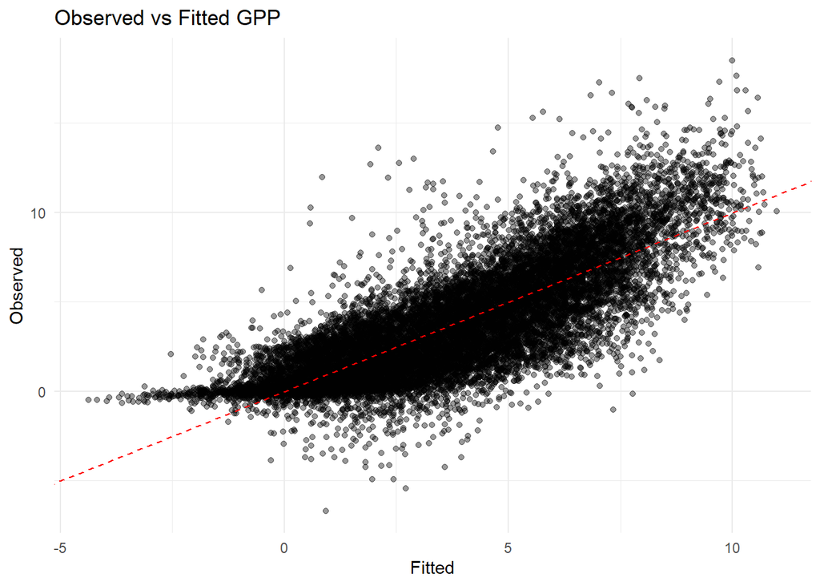

```r
ggplot(data.frame(observed = model.frame(final_model)$GPP_NT_VUT_REF,
                  fitted = fitted(final_model)),
       aes(x = fitted, y = observed)) +
  geom_point(alpha = 0.4) +
  geom_abline(slope = 1, intercept = 0, color = "red", linetype = "dashed") +
  labs(title = "Observed vs Fitted GPP", x = "Fitted", y = "Observed") +
  theme_minimal()
```

Finally, we can have a look at the plot of the observed values in the data set against the fitted values from our final model. Overall the model doesn’t perform too bad. Yet we can clearly see a curved pattern that indicates that a more flexible model (for example quadratic) might be more appropriate. The model clearly underpredicts for low values of GPP and from the curved pattern, it seems that high values of GPP tend to be underpredicted as well.